# Practical Machine Learning Assignment. Data Science Specialization

Eduardo Bravo

21st July, 2019

## Executive Summary

One thing that people regularly do is quantify how much of a particular activity they do, but they rarely quantify how well they do it. In this project, my goal will be to use data from accelerometers on the belt, forearm, arm, and dumbell of 6 participants to predict the manner in which they did the exercise. This is the “classe” variable in the training set.

Using devices such as Jawbone Up, Nike FuelBand, and Fitbit it is now possible to collect a large amount of data about personal activity relatively inexpensively. These type of devices are part of the quantified self movement - a group of enthusiasts who take measurements about themselves regularly to improve their health, to find patterns in their behavior, or because they are tech geeks. One thing that people regularly do is quantify how much of a particular activity they do, but they rarely quantify how well they do it. In this project, your goal will be to use data from accelerometers on the belt, forearm, arm, and dumbell of 6 participants. They were asked to perform barbell lifts correctly and incorrectly in 5 different ways. More information is available from the website here: http://web.archive.org/web/20161224072740/http:/groupware.les.inf.puc-rio.br/har (see the section on the Weight Lifting Exercise Dataset).

## Preparing the environment

Here we will load all the required libraries for the analysis and set the working directory.

```r
setwd('E:/Programming/Practical-Machine-Learning-Assignment')
library(caret, quietly = TRUE)
library(ggplot2, quietly = TRUE)
library(randomForest, quietly = TRUE)
library(doParallel, quietly = TRUE)
library(gbm, quietly = TRUE)
```

## Loading Data

We load the data for the exercise.

```r
trainURL <- 'https://d396qusza40orc.cloudfront.net/predmachlearn/pml-training.csv'
testURL <- 'https://d396qusza40orc.cloudfront.net/predmachlearn/pml-testing.csv'

trainDF <- read.csv(url(trainURL), header = TRUE)
testDF <- read.csv(url(testURL), header = TRUE)
```

## Number of Variables Reduction

```r
# deleting those variables with very low variance
reducedVar <- nearZeroVar(trainDF)
trainDF <- trainDF[,-reducedVar]

# deleting those variables with more than a 90% of NAs within their observations
for (i in 1:length(trainDF)) {
        if (mean(is.na(trainDF)[,i]) > 0.9) {
                colnames(trainDF)[i] <- paste(colnames(trainDF[i]), 'NAs', sep = '-')
        }
}
trainDF <- trainDF[grep("-NAs", colnames(trainDF), invert = TRUE)]

# Deleting the first 5 variables that are indexes
trainDF <- trainDF[,6:length(trainDF)]
dim(trainDF)
```

```
## [1] 19622    54
```

The new number of variables is 54

## Model Selection

First, even though we have a testing df with the final 20 observations to test, we will split the training set into train and validation sets so we can compare different models before actually applying the model to those 20 obs.

```r
inTrain  <- createDataPartition(trainDF$classe, p=0.7, list=FALSE)
trainSubset <- trainDF[inTrain, ]
testSubset  <- trainDF[-inTrain, ]
```

Now we’ll use the main different models to predict a categorycal variable with more than two categories. Plots, final models and confusio Matrixes in detail can be seen in Appendix II.

```r
#RANDOM FOREST: Model building
set.seed(666)
modelRF <- train(classe ~ .,
                 data=trainSubset,
                 method="rf",
                 trControl=trainControl(method="cv",
                                        number=5,
                                        verboseIter=FALSE)
                 )


# RANDOM FOREST: Prediction on TestSubset
predictRF <- predict(modelRF, newdata=testSubset)
confusionMatrixRF <- confusionMatrix(predictRF, testSubset$classe)
print('RANDOM FOREST')
```

```
## [1] "RANDOM FOREST"
```

```r
confusionMatrixRF$overall
```

```
##       Accuracy          Kappa  AccuracyLower  AccuracyUpper   AccuracyNull
##      0.9984707      0.9980656      0.9970989      0.9993005      0.2844520
## AccuracyPValue  McnemarPValue
##      0.0000000            NaN
```

```r
# NEURAL NETWORK: Model building

registerDoParallel(cores = 2)
modelNNET <- train(classe ~ .,
                   data = trainSubset,
                   method = 'nnet',
                   preProcess = c('center', 'scale'),
                   trControl = trainControl(method = 'cv',
                                            number = 10,
                                            classProbs = TRUE,
                                            verboseIter = FALSE,
                                            preProcOptions = list(thresh = 0.75,
                                                                  ICAcomp = 3,
                                                                  k = 5)),
                   tuneGrid=expand.grid(size=c(10),
                                        decay=c(0.1)
                                        )
                   )
# NEURAL NETWORK: Prediction on TestSubset
predictNNET <- predict(modelNNET, newdata=testSubset)
confusionMatrixNNET <- confusionMatrix(predictNNET, testSubset$classe)
print('NEURAL NETWORK')
```

```
## [1] "NEURAL NETWORK"
```

```r
confusionMatrixNNET$overall
```

```
##       Accuracy          Kappa  AccuracyLower  AccuracyUpper   AccuracyNull
##   8.521665e-01   8.127979e-01   8.428389e-01   8.611435e-01   2.844520e-01
## AccuracyPValue  McnemarPValue
##   0.000000e+00   3.747864e-10
```

```r
# BOOSTING: Model building
set.seed(666)
modelBOOST  <- train(classe ~ .,
                     data=trainSubset,
                     method = "gbm",
                     trControl = trainControl(method = "repeatedcv",
                                              number = 3,
                                              repeats = 2),
                     verbose = FALSE)

# BOOSTING: Prediction on TestSubset
predictBOOST <- predict(modelBOOST, newdata=testSubset)
confusionMatrixBOOST <- confusionMatrix(predictBOOST, testSubset$classe)
print('BOOSTING')
```

```
## [1] "BOOSTING"
```

```r
confusionMatrixBOOST$overall
```

```
##       Accuracy          Kappa  AccuracyLower  AccuracyUpper   AccuracyNull
##      0.9887850      0.9858120      0.9857536      0.9913160      0.2844520
## AccuracyPValue  McnemarPValue
##      0.0000000            NaN
```

As can be seen, the random forest model is the one with higher accuracy with a 0.9984707. We will use this model to predict the final test set.

```r
predictTestRF <- predict(modelRF, newdata=testDF)
predictTestRF
```

```
##  [1] B A B A A E D B A A B C B A E E A B B B
## Levels: A B C D E
```

## Appendixes

### Appendix I

```r
str(trainDF)
```

```
## 'data.frame':    19622 obs. of  54 variables:
##  $ num_window          : int  11 11 11 12 12 12 12 12 12 12 ...
##  $ roll_belt           : num  1.41 1.41 1.42 1.48 1.48 1.45 1.42 1.42 1.43 1.45 ...
##  $ pitch_belt          : num  8.07 8.07 8.07 8.05 8.07 8.06 8.09 8.13 8.16 8.17 ...
##  $ yaw_belt            : num  -94.4 -94.4 -94.4 -94.4 -94.4 -94.4 -94.4 -94.4 -94.4 -94.4 ...
##  $ total_accel_belt    : int  3 3 3 3 3 3 3 3 3 3 ...
##  $ gyros_belt_x        : num  0 0.02 0 0.02 0.02 0.02 0.02 0.02 0.02 0.03 ...
##  $ gyros_belt_y        : num  0 0 0 0 0.02 0 0 0 0 0 ...
##  $ gyros_belt_z        : num  -0.02 -0.02 -0.02 -0.03 -0.02 -0.02 -0.02 -0.02 -0.02 0 ...
##  $ accel_belt_x        : int  -21 -22 -20 -22 -21 -21 -22 -22 -20 -21 ...
##  $ accel_belt_y        : int  4 4 5 3 2 4 3 4 2 4 ...
##  $ accel_belt_z        : int  22 22 23 21 24 21 21 21 24 22 ...
##  $ magnet_belt_x       : int  -3 -7 -2 -6 -6 0 -4 -2 1 -3 ...
##  $ magnet_belt_y       : int  599 608 600 604 600 603 599 603 602 609 ...
##  $ magnet_belt_z       : int  -313 -311 -305 -310 -302 -312 -311 -313 -312 -308 ...
```

[output cut: 40 more lines]

```r
summary(trainDF)
```

```
##    num_window      roll_belt        pitch_belt          yaw_belt
##  Min.   :  1.0   Min.   :-28.90   Min.   :-55.8000   Min.   :-180.00
##  1st Qu.:222.0   1st Qu.:  1.10   1st Qu.:  1.7600   1st Qu.: -88.30
##  Median :424.0   Median :113.00   Median :  5.2800   Median : -13.00
##  Mean   :430.6   Mean   : 64.41   Mean   :  0.3053   Mean   : -11.21
##  3rd Qu.:644.0   3rd Qu.:123.00   3rd Qu.: 14.9000   3rd Qu.:  12.90
##  Max.   :864.0   Max.   :162.00   Max.   : 60.3000   Max.   : 179.00
##  total_accel_belt  gyros_belt_x        gyros_belt_y       gyros_belt_z
##  Min.   : 0.00    Min.   :-1.040000   Min.   :-0.64000   Min.   :-1.4600
##  1st Qu.: 3.00    1st Qu.:-0.030000   1st Qu.: 0.00000   1st Qu.:-0.2000
##  Median :17.00    Median : 0.030000   Median : 0.02000   Median :-0.1000
##  Mean   :11.31    Mean   :-0.005592   Mean   : 0.03959   Mean   :-0.1305
##  3rd Qu.:18.00    3rd Qu.: 0.110000   3rd Qu.: 0.11000   3rd Qu.:-0.0200
##  Max.   :29.00    Max.   : 2.220000   Max.   : 0.64000   Max.   : 1.6200
##   accel_belt_x       accel_belt_y     accel_belt_z     magnet_belt_x
##  Min.   :-120.000   Min.   :-69.00   Min.   :-275.00   Min.   :-52.0
##  1st Qu.: -21.000   1st Qu.:  3.00   1st Qu.:-162.00   1st Qu.:  9.0
##  Median : -15.000   Median : 35.00   Median :-152.00   Median : 35.0
##  Mean   :  -5.595   Mean   : 30.15   Mean   : -72.59   Mean   : 55.6
##  3rd Qu.:  -5.000   3rd Qu.: 61.00   3rd Qu.:  27.00   3rd Qu.: 59.0
##  Max.   :  85.000   Max.   :164.00   Max.   : 105.00   Max.   :485.0
##  magnet_belt_y   magnet_belt_z       roll_arm         pitch_arm
##  Min.   :354.0   Min.   :-623.0   Min.   :-180.00   Min.   :-88.800
##  1st Qu.:581.0   1st Qu.:-375.0   1st Qu.: -31.77   1st Qu.:-25.900
##  Median :601.0   Median :-320.0   Median :   0.00   Median :  0.000
##  Mean   :593.7   Mean   :-345.5   Mean   :  17.83   Mean   : -4.612
##  3rd Qu.:610.0   3rd Qu.:-306.0   3rd Qu.:  77.30   3rd Qu.: 11.200
##  Max.   :673.0   Max.   : 293.0   Max.   : 180.00   Max.   : 88.500
##     yaw_arm          total_accel_arm  gyros_arm_x        gyros_arm_y
##  Min.   :-180.0000   Min.   : 1.00   Min.   :-6.37000   Min.   :-3.4400
##  1st Qu.: -43.1000   1st Qu.:17.00   1st Qu.:-1.33000   1st Qu.:-0.8000
##  Median :   0.0000   Median :27.00   Median : 0.08000   Median :-0.2400
##  Mean   :  -0.6188   Mean   :25.51   Mean   : 0.04277   Mean   :-0.2571
##  3rd Qu.:  45.8750   3rd Qu.:33.00   3rd Qu.: 1.57000   3rd Qu.: 0.1400
##  Max.   : 180.0000   Max.   :66.00   Max.   : 4.87000   Max.   : 2.8400
##   gyros_arm_z       accel_arm_x       accel_arm_y      accel_arm_z
##  Min.   :-2.3300   Min.   :-404.00   Min.   :-318.0   Min.   :-636.00
##  1st Qu.:-0.0700   1st Qu.:-242.00   1st Qu.: -54.0   1st Qu.:-143.00
##  Median : 0.2300   Median : -44.00   Median :  14.0   Median : -47.00
##  Mean   : 0.2695   Mean   : -60.24   Mean   :  32.6   Mean   : -71.25
```

[output cut: 50 more lines]

```
##  Max.   :311.00000   Max.   :231.0000   Max.   : 477.00   Max.   : 923.0
##  accel_forearm_z   magnet_forearm_x  magnet_forearm_y magnet_forearm_z
##  Min.   :-446.00   Min.   :-1280.0   Min.   :-896.0   Min.   :-973.0
##  1st Qu.:-182.00   1st Qu.: -616.0   1st Qu.:   2.0   1st Qu.: 191.0
##  Median : -39.00   Median : -378.0   Median : 591.0   Median : 511.0
##  Mean   : -55.29   Mean   : -312.6   Mean   : 380.1   Mean   : 393.6
##  3rd Qu.:  26.00   3rd Qu.:  -73.0   3rd Qu.: 737.0   3rd Qu.: 653.0
##  Max.   : 291.00   Max.   :  672.0   Max.   :1480.0   Max.   :1090.0
##  classe
##  A:5580
##  B:3797
##  C:3422
##  D:3216
##  E:3607
##
```

### Appendix II

```r
#RANDOM FOREST

print('RANDOM FOREST')
```

```
## [1] "RANDOM FOREST"
```

```r
modelRF$finalModel
```

```
##
## Call:
##  randomForest(x = x, y = y, mtry = param$mtry)
##                Type of random forest: classification
##                      Number of trees: 500
## No. of variables tried at each split: 27
##
##         OOB estimate of  error rate: 0.26%
## Confusion matrix:
##      A    B    C    D    E  class.error
## A 3905    0    0    0    1 0.0002560164
## B    7 2647    3    1    0 0.0041384500
## C    0    7 2389    0    0 0.0029215359
## D    0    0   12 2240    0 0.0053285968
## E    0    1    0    4 2520 0.0019801980
```

```r
confusionMatrixRF
```

```
## Confusion Matrix and Statistics
##
##           Reference
## Prediction    A    B    C    D    E
##          A 1673    1    0    0    0
##          B    1 1136    1    0    0
##          C    0    1 1025    3    0
##          D    0    1    0  961    1
##          E    0    0    0    0 1081
##
## Overall Statistics
##
##                Accuracy : 0.9985
##                  95% CI : (0.9971, 0.9993)
##     No Information Rate : 0.2845
##     P-Value [Acc > NIR] : < 2.2e-16
##
##                   Kappa : 0.9981
##
##  Mcnemar's Test P-Value : NA
##
## Statistics by Class:
##
##                      Class: A Class: B Class: C Class: D Class: E
## Sensitivity            0.9994   0.9974   0.9990   0.9969   0.9991
## Specificity            0.9998   0.9996   0.9992   0.9996   1.0000
## Pos Pred Value         0.9994   0.9982   0.9961   0.9979   1.0000
## Neg Pred Value         0.9998   0.9994   0.9998   0.9994   0.9998
## Prevalence             0.2845   0.1935   0.1743   0.1638   0.1839
## Detection Rate         0.2843   0.1930   0.1742   0.1633   0.1837
## Detection Prevalence   0.2845   0.1934   0.1749   0.1636   0.1837
## Balanced Accuracy      0.9996   0.9985   0.9991   0.9982   0.9995
```

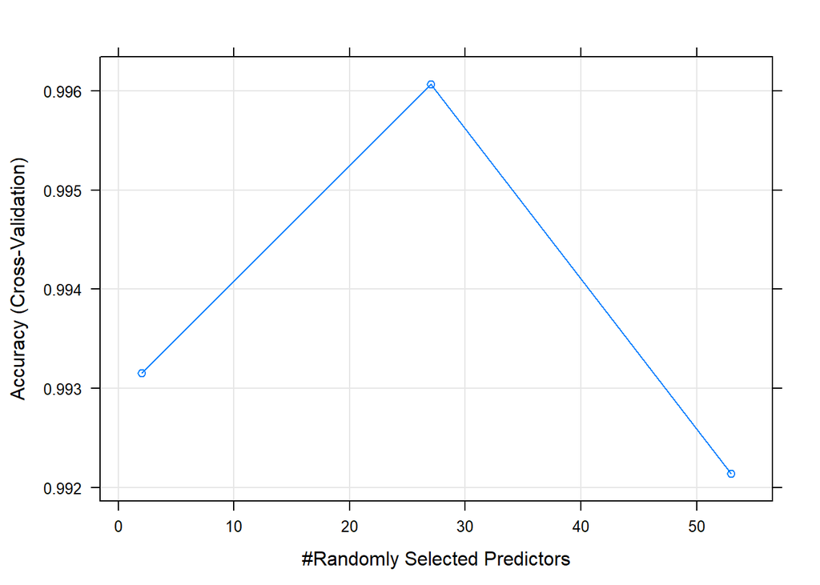

```r
plot(modelRF)
```

```r
# NEURAL NETWORK

print('NEURAL NETWORK')
```

```
## [1] "NEURAL NETWORK"
```

```r
modelNNET$finalModel
```

[output not shown]

```r
confusionMatrixNNET
```

```
## Confusion Matrix and Statistics
##
##           Reference
## Prediction    A    B    C    D    E
##          A 1561  127   13   40    6
##          B   50  849   43   24   46
##          C   14  101  873   75   42
##          D   45   15   68  792   48
##          E    4   47   29   33  940
##
## Overall Statistics
##
##                Accuracy : 0.8522
##                  95% CI : (0.8428, 0.8611)
##     No Information Rate : 0.2845
##     P-Value [Acc > NIR] : < 2.2e-16
##
##                   Kappa : 0.8128
##
##  Mcnemar's Test P-Value : 3.748e-10
##
## Statistics by Class:
##
##                      Class: A Class: B Class: C Class: D Class: E
## Sensitivity            0.9325   0.7454   0.8509   0.8216   0.8688
## Specificity            0.9558   0.9657   0.9523   0.9642   0.9765
## Pos Pred Value         0.8935   0.8389   0.7900   0.8182   0.8927
## Neg Pred Value         0.9727   0.9405   0.9680   0.9650   0.9706
## Prevalence             0.2845   0.1935   0.1743   0.1638   0.1839
## Detection Rate         0.2653   0.1443   0.1483   0.1346   0.1597
## Detection Prevalence   0.2969   0.1720   0.1878   0.1645   0.1789
## Balanced Accuracy      0.9442   0.8555   0.9016   0.8929   0.9226
```

```r
# BOOSTING

print('BOOSTING')
```

```
## [1] "BOOSTING"
```

```r
modelBOOST$finalModel
```

```
## A gradient boosted model with multinomial loss function.
## 150 iterations were performed.
## There were 53 predictors of which 53 had non-zero influence.
```

```r
confusionMatrixBOOST
```

```
## Confusion Matrix and Statistics
##
##           Reference
## Prediction    A    B    C    D    E
##          A 1668   13    0    1    0
##          B    6 1116    8    5    4
##          C    0   10 1015    9    2
##          D    0    0    3  949    5
##          E    0    0    0    0 1071
##
## Overall Statistics
##
##                Accuracy : 0.9888
##                  95% CI : (0.9858, 0.9913)
##     No Information Rate : 0.2845
##     P-Value [Acc > NIR] : < 2.2e-16
##
##                   Kappa : 0.9858
##
##  Mcnemar's Test P-Value : NA
##
## Statistics by Class:
##
##                      Class: A Class: B Class: C Class: D Class: E
## Sensitivity            0.9964   0.9798   0.9893   0.9844   0.9898
## Specificity            0.9967   0.9952   0.9957   0.9984   1.0000
## Pos Pred Value         0.9917   0.9798   0.9797   0.9916   1.0000
## Neg Pred Value         0.9986   0.9952   0.9977   0.9970   0.9977
## Prevalence             0.2845   0.1935   0.1743   0.1638   0.1839
## Detection Rate         0.2834   0.1896   0.1725   0.1613   0.1820
## Detection Prevalence   0.2858   0.1935   0.1760   0.1626   0.1820
## Balanced Accuracy      0.9965   0.9875   0.9925   0.9914   0.9949
```

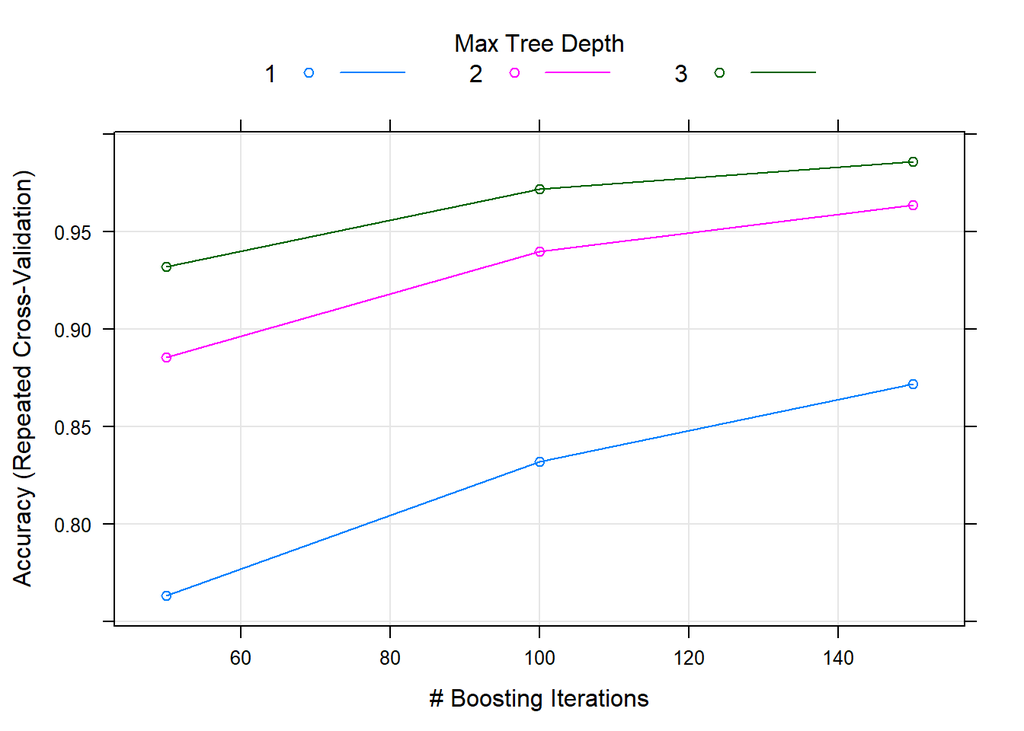

```r
plot(modelBOOST)
```